# Adrian Newey: La revolución aerodinámica y el análisis de datos en la Fórmula 1

*«El reto consiste en hacerlo más rápido que nadie sin perder el control. Eso es un nivel completamente distinto.»*

Elena Corbalán

Sergio Martín

Igor Asenjo

## Presentación

**Personaje histórico:** Adrian Newey.  
**Deporte:** Automovilismo (Fórmula 1, IndyCar, IMSA).  
**Ámbito analítico:** Simulación aerodinámica, telemetría y algoritmos de control de chasis.

[figure not shown]

Newey en McLaren y en Aston Martin. Foto de motor.es

## Contexto: La F1 empírica antes de los datos

Durante los años 70, el diseño dependía en gran medida de la **genialidad e intuición** de diseñadores individuales como Colin Chapman o el propio Adrian Newey en sus inicios, bajo un método dominante de *construir, probar y corregir*. Las decisiones sobre la puesta a punto se tomaban basándose principalmente en los tiempos por vuelta marcados a mano y en el feedback subjetivo del piloto. Asimismo, no existía el análisis de datos en tiempo real ni la capacidad de cruzar variables en un ordenador para comparar, por ejemplo, la aceleración lateral con la presión de freno y la altura del chasis.

Mientras que en esta década el desarrollo estuvo basado en el empirismo y la aerodinámica se probaba directamente en pista añadiendo o quitando piezas sin sensores digitales a bordo, la década de 1980 marcó el inicio del cambio de paradigma. A mediados de esa década, escuderías como Williams o McLaren empezaron a **instalar dataloggers primitivos** que almacenaban información en memoria interna para descargarla por cable en boxes, iniciando así la medición cuantitativa de parámetros básicos como revoluciones por minuto, presiones, temperaturas y velocidad de las ruedas.

## Biografía breve: De la aeronáutica a la pista

Adrian Newey (nacido en 1958) es un ingeniero británico graduado en Aeronáutica y Astronáutica por la Universidad de Southampton, donde se especializó en aerodinámica de efecto suelo. Es considerado una de las figuras más laureadas de la historia del automovilismo y el diseñador que transformó el rol de la ingeniería al **integrar la recolección masiva de datos experimentales del túnel de viento con la puesta a punto en pista**.

Su carrera despegó en los años 80. Tras sus primeros pasos en Fittipaldi y en March IndyCar —donde llegó a ganar las 500 Millas de Inianápolis en 1983—, dio el salto a la Fórmula 1 con FORCE. Posteriormente regresó a March (luego Leyton House), donde fue fuertemente criticado por dar una importancia excesiva a la aerodinámica frente a otros componentes, un enfoque pionero que le costó incluso ser despedido.

Williams apostó por su talento ofreciéndole un mayor presupuesto y recursos. Conquistó cuatro mundiales de pilotos y cuatro de constructores con figuras como Nigel Mansell (1992), Alain Prost (1993), Damon Hill (1996) y Jacques Villeneuve (1997). En esta etapa también vivió uno de los momentos más trágicos de su carrera con el fallecimiento de Ayrton Senna en el GP de San Marino de 1994.

Consagrado como el mejor diseñador del momento, se unió a McLaren para construir el monoplaza que llevó a Mika Häkkinen a ganar dos campeonatos de pilotos consecutivos en 1998 y 1999.

Llegó a la escudería Red Bull en 2006 y, a partir de 2009, **revolucionó el diseño de sus coches**. Lideró la era dorada de Sebastian Vettel con cuatro dobles coronas consecutivas (2010-2013) y sentó las bases para el posterior dominio de Max Verstappen a partir de 2021, batiendo récords absolutos de puntos en una temporada tanto con Vettel (2011) como con Verstappen (2023).

Tras 18 años y **25 títulos mundiales** combinados (13 de Pilotos y 12 de Constructores) repartidos entre Williams, McLaren y Red Bull, Newey cerró su fructífera etapa en la escudería de la bebida energética para iniciar un nuevo capítulo en Aston Martin.

## Contribución principal: Análisis y validación cuantitativa

La aportación técnica fundamental de Newey al *Sports Analytics* fue la estandarización del método científico en el diseño de monoplazas:

- **Mapeo fluidodinámico:** Implementó la técnica *Flow Vis* (pintura fluorescente) y sensores de presión estática para transformar los flujos de aire en conjuntos de datos visuales y numéricos interpretables.
- **Metodología A-B-A en pista:** Instauró protocolos estadísticos estrictos de prueba en los circuitos para aislar variables mecánicas de factores de confusión externos (como desgaste de gomas o temperatura de asfalto).
- **Control algorítmico del vehículo:** Lideró la convergencia entre aerodinámica, sensores en tiempo real y *software* de control mediante el desarrollo de las primeras suspensiones activas fiables.

## Impacto en el deporte I: Empaquetamiento y aerodinámica

Newey cambió radicalmente la morfología de la F1 al tratar el coche como un sistema de datos holístico, donde masa y dinámica de fluidos interactúan sin descanso.

Con el **March 881 (Leyton House, 1988)**, demostró empíricamente que la reducción drástica del espacio interior mejoraba el flujo volumétrico. Hasta ese momento, las cabinas (cockpits) de los F1 eran relativamente espaciosas y cuadradas para dar comodidad al piloto y acomodar los componentes. Newey entendió que la sección transversal del coche actuaba como un obstáculo para el aire. Al reducir al mínimo absoluto el espacio interior (encogiendo el chasis alrededor del cuerpo del piloto), disminuyó la resistencia al avance (drag) y canalizó un volumen de aire mucho mayor y más limpio hacia la parte trasera y el difusor, aumentando la carga aerodinámica (downforce).

[figure not shown]

March 881 (Leyton House, 1988)

Introdujo el chasis en forma de “V” y elevó la caja de pedales para independizar el flujo del alerón delantero del morro. Las tolerancias analíticas eran tan extremas que requirieron alteraciones asimétricas del monocasco en fibra de carbono simplemente para que los nudillos de pilotos como Ivan Capelli pudieran accionar la caja de cambios.

## Impacto en el deporte II: La revolución del algoritmo (FW14B)

El **Williams FW14B** (1992) representa el punto de inflexión definitivo donde el *software* dominó al *hardware*. Hasta ese momento, el comportamiento de un coche dependía de su hardware pasivo (muelles, amortiguadores y barras estabilizadoras).Newey integró un sistema de suspensión activa controlada por una centralita electrónica que bombeaba fluido a actuadores hidráulicos mediante válvulas proporcionales Moog. Así un microprocesador decidía en cada milisegundo qué altura debía tener cada rueda, abriendo o cerrando el paso del fluido hidráulico milimétricamente para subir, bajar, endurecer o ablandar la suspensión de cada rueda de forma independiente y casi instantánea.

Este algoritmo absorbía los datos de las fuerzas G laterales y longitudinales, corrigiendo en milisegundos la plataforma del coche para mantener una altura de manejo (*ride-height*) óptima en todo momento. Esta innovación analítica anuló la transferencia de masas y reescribió las reglas del deporte, logrando un dominio tan abrumador que la FIA terminó prohibiendo las ayudas electrónicas.

## Impacto en el deporte III: Los límites de la simulación

El análisis de datos no está exento de colapsos cuando los modelos teóricos difieren de la física real.

- **Williams FW16 (1994):** Tras la prohibición algorítmica, el modelo pasivo sufrió de separación de flujos. La constricción entre el suelo y los pontones frontales al frenar causaba un *stall* violento del difusor trasero, evidenciando las limitaciones de un diseño que dependía de la corrección informática abolida. Sin la informática corrigiendo la altura del coche, al frenar antes de una curva, la inercia hacía que el morro se hundiera y la parte trasera se elevara de forma abrupta. Esto alteraba radicalmente la distancia entre el suelo del coche y el asfalto, el difusor dejaba de generar agarre de golpe y el eje trasero perdía toda la adherencia de forma impredecible y violenta.
- **McLaren MP4-18 y Red Bull RB3:** Proyectos posteriores demostraron que el modelado extremo en Mecánica de Fluidos Computacional (CFD) y tunel de viento, como el chasis de “doble quilla” o cajas de cambio ultra-compactas, podía generar fallos catastróficos no previstos en los simuladores, como la ruptura prematura de vórtices bajo guiñada, incendios sistémicos por estrés térmico y fricción de transmisión.

## Influencia en el análisis moderno

El legado de Newey sentó los pilares del *Sports Analytics* actual en el automovilismo (Ingeniería Predictiva):

- **CFD y Gemelos Digitales:** Fue pionero en exigir una triangulación analítica perfecta entre tres entornos: la simulación virtual (CFD), el túnel de viento (física a escala) y la telemetría en pista (física real).
- **Telemetría y Set-up dinámico:** A medida que la electrónica y la adquisición de datos evolucionaron, Newey entendió que el coche cambia drásticamente a lo largo de una carrera. Incorporó ajustes en el volante para que el piloto optimizara hiperparámetros, como reparto de frenada o mapas motor, en tiempo real, transformándolo en un analista activo.
- **Estrategia Estocástica Moderna:** En la Fórmula 1 actual, el análisis de datos no se limita a la aerodinámica del monoplaza; domina por completo la toma de decisiones estratégicas durante los Grandes Premios. Hoy en día, estructuras como Aston Martin utilizan la base teórica de validación de Newey para ejecutar simulaciones de Montecarlo. Si los datos teóricos de un modelo de simulación fallan al chocar con la realidad de la pista (por ejemplo, si el desgaste real del neumático es mayor al previsto en el software), el marco analítico compensa la desviación recalibrando los modelos estocásticos sobre la marcha.

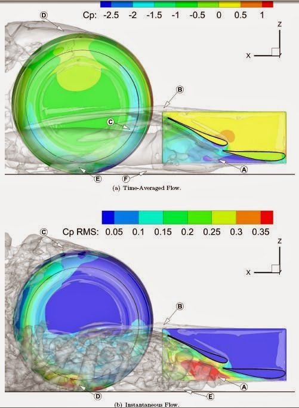

The aerodynamics of an inverted wing and a rotating wheel in ground effect

## Ideas que siguen vigentes: El sesgo de datos

Uno de los postulados históricos de Adrian Newey con mayor vigencia en la ciencia de datos moderna es la advertencia contra el **peligro del sobreajuste (overfitting) y la ceguera por calibración instrumental**.

Durante su etapa en March/Leyton House a finales de los años 80, el equipo diseñó un coche cuyos modelos aerodinámicos en el túnel de viento predecían un rendimiento perfecto, pero en pista resultaba errático e inestable. Mediante un riguroso proceso de aislamiento de variables y auditoría de las herramientas de medición, Newey descubrió que las estructuras de madera bajo la sección de pruebas del túnel se habían combado por la propia fuerza de succión del aire, alterando el canal de flujo y generando un diferencial de presión artificial con lecturas de carga fantasma. Este sesgo masivo en los datos de entrenamiento (Data Bias) demostró que cualquier algoritmo o modelo predictivo es tan bueno como la pureza de la información que lo alimenta (Garbage In, Garbage Out), convirtiendo a la estricta calibración instrumental para **garantizar la «correlación pista-simulador» en la ley fundamental de la Fórmula 1 actual**.

> *“La gente me pregunta si me siento culpable por Ayrton. Sí, me siento culpable. Yo era uno de los oficiales superiores de un equipo que diseñó un coche en el que murió un gran hombre. Independientemente de si la columna de dirección causó el accidente o no, es innegable que fue un diseño deficiente que nunca debería haber llegado al coche. El sistema que Patrick y yo teníamos implementado era inadecuado; eso es indiscutible. Nuestra falta de un sistema de control de seguridad en la oficina de diseño quedó al descubierto”*. Adrian Newey

## Cierre y reflexión final

Adrian Newey demostró que la ventaja competitiva en el deporte del motor no reside en corazonadas, sino en la capacidad para adquirir, depurar y correlacionar miles de puntos de datos de ingeniería dinámica. Al fusionar el rigor metodológico aeronáutico con el diseño de chasis, lideró la transformación de la Fórmula 1 hacia la era de la inteligencia predictiva.

> “Treinta y cinco años despué puedo mirar atrás a una carrera intensa y fructífera, dedicada al diseño de automóviles y a hacerme siempre las mismas preguntas sencillas: ¿Cómo podemos aumentar el rendimiento? ¿Cómo podemos mejorar la eficiencia? ¿Cómo podemos hacerlo de otra manera?  
> ¿Cómo puedo hacerlo mejor?” Adrian Newey

## Bibliografía

Mancebo, A. (2024). *March 881, la historia de la primera genialidad de Adrian Newey en la F1*. Auto Bild.

McCabe, G. (2014). *Adrian Newey and unsteady CFD*.

Newey, A. (2017). *How to build a car*. HarperCollinsPublishers.